# Toán ứng dụng và thống kê

# 1. Thông tin sinh viên

- Họ và tên: Nguyễn Gia Huy
- MSSV: 22127154
- Lớp: 22CLC06

# 2. Giới thiệu đồ án và ý tưởng thực hiện

## 2.1. Giới thiệu đồ án

Đồ án này nhằm xây dựng mô hình dự đoán chất lượng rượu vang dựa trên cơ sở dữ liệu gồm 1200 mẫu rượu vang với 11 đặc trưng khác nhau. Chúng ta sẽ sử dụng phương pháp hồi quy tuyến tính để xây dựng mô hình dự đoán chất lượng rượu vang.

Yêu cầu của đồ án: a. Xây dựng mô hình hồi quy tuyến tính sử dụng toàn bộ 11 đặc trưng. b. Xây dựng mô hình hồi quy tuyến tính sử dụng duy nhất 1 đặc trưng cho kết quả tốt nhất. c. Xây dựng một mô hình của riêng để cho kết quả tốt nhất.

## 2.2 Ý tưởng thực hiện

### 2.2.1 Xây dựng mô hình hồi quy tuyến tính sử dụng toàn bộ 11 đặc trưng

Đối với yêu cầu này, chúng ta sẽ sử dụng toàn bộ 11 đặc trưng để xây dựng mô hình hồi quy tuyến tính. Để đánh giá mô hình, chúng ta sẽ sử dụng độ đo bình phương trung bình của sai số (Mean Squared Error - MSE).

Chúng ta sẽ xây dựng model tuyến tính có dạng: $$ y = w_0 + w_1x_1 + w_2x_2 + ... + w_nx_n $$

Trong đó:

- $y$ là chất lượng rượu vang.
- $x_1, x_2, ..., x_n$ là các đặc trưng của rượu vang.
- $w_0, w_1, w_2, ..., w_n$ là các hệ số cần tìm. (Trong đó $w_0$ là hệ số chặn).

### 2.2.2 Xây dựng mô hình hồi quy tuyến tính sử dụng duy nhất 1 đặc trưng cho kết quả tốt nhất

Đối với yêu cầu này, chúng ta sẽ sử dụng duy nhất 1 đặc trưng để xây dựng mô hình hồi quy tuyến tính. Để đánh giá mô hình, chúng ta sẽ sử dụng độ đo bình phương trung bình của sai số (Mean Squared Error - MSE).

Chúng ta sẽ xây dựng model tuyến tính có dạng: $$ y = w_0 + w_1x_1 $$

Trong đó:

- $y$ là chất lượng rượu vang.
- $x_1$ là đặc trưng của rượu vang.
- $w_0, w_1$ là các hệ số cần tìm. (Trong đó $w_0$ là hệ số chặn).

Chúng ta sẽ thử nghiệm với từng đặc trưng để chọn ra đặc trưng tốt nhất cho mô hình.

### 2.2.3 Xây dựng một mô hình của riêng để cho kết quả tốt nhất

Đối với yêu cầu này, chúng ta sẽ sử dụng một mô hình riêng để cho kết quả tốt nhất. Để đánh giá mô hình, chúng ta sẽ sử dụng độ đo bình phương trung bình của sai số (Mean Squared Error - MSE).

Chúng ta có thể xây dựng một số mô hình khác nhau như:

- Mô hình hồi quy tuyến tính bậc 1: $y = w_0 + w_1x_1$
- Mô hình hồi quy tuyến tính bậc 2: $y = w_0 + w_1x_1 + w_2x_1^2$
- Mô hình hồi quy tuyến tính bậc 3: $y = w_0 + w_1x_1 + w_2x_1^2 + w_3x_1^3$
- Mô hình tuyến tính - log: $y = w_0 + w_1\ln(x_1)$
- Mô hình log - tuyến tính: $\ln(y) = w_0 + w_1x_1$
- Mô hình log - log: $\ln(y) = w_0 + w_1\ln(x_1)$

# 3. Cài đặt

## 3.1. Import thư viện

```python
import pandas as pd  # type: ignore - Thư viện dùng để xử lý dữ liệu dạng bảng (dataframe)
import numpy as np  # type: ignore - Thư viện dùng để xử lý dữ liệu dạng ma trận và các phép toán liên quan
import matplotlib.pyplot as plt  # type: ignore - Thư viện dùng để vẽ biểu đồ
from typing import List, Tuple  # type: ignore - Thư viện hỗ trợ kiểu dữ liệu
from numpy.typing import ArrayLike
```

## 3.2. Đọc dữ liệu và tiền xử lý

Chia dữ liệu thành 2 phần sẽ giúp chúng ta đánh giá mô hình xây dựng được trên tập dữ liệu mới mà mô hình chưa từng thấy trước đó.

```python
# Đọc dữ liệu từ file "wine.csv"

data = pd.read_csv("wine.csv", delimiter=";")

# Chia dữ liệu thành 2 phần: dữ liệu đầu vào và dữ liệu đầu ra
X = data.iloc[:, :-1].values
y = data.iloc[:, -1].values

features = data.columns[:-1]  # Tên các đặc trưng


# # Loại bỏ các hàng có giá trị 0 hoặc âm
# def remove_zeros_and_negatives(X, y):
#     mask = np.all(X > 0, axis=1) & (y > 0)
#     return X[mask], y[mask]


# X, y = remove_zeros_and_negatives(X, y)


# Hàm chia dữ liệu thành tập huấn luyện và tập kiểm tra
def train_test_split(X, y, test_size=0.2, random_state=42):
    np.random.seed(random_state)
    indices = np.random.permutation(X.shape[0])
    test_size = int(X.shape[0] * test_size)
    test_indices = indices[:test_size]
    train_indices = indices[test_size:]
    return X[train_indices], X[test_indices], y[train_indices], y[test_indices]
```

## 3.3 Xây dựng mô hình hồi quy tuyến tính sử dụng toàn bộ 11 đặc trưng

Minh họa một mô hình hồi quy tuyến tính với 11 biến độc lập có thể phức tạp nếu ta cố gắng biểu diễn toàn bộ dữ liệu trong không gian 2D hay 3D. Một cách tối ưu và đơn giản nhất là sử dụng biểu đồ trọng số (weights chart) của các hệ số hồi quy, bởi vì nó cho thấy mức độ ảnh hưởng của mỗi biến đến đầu ra.

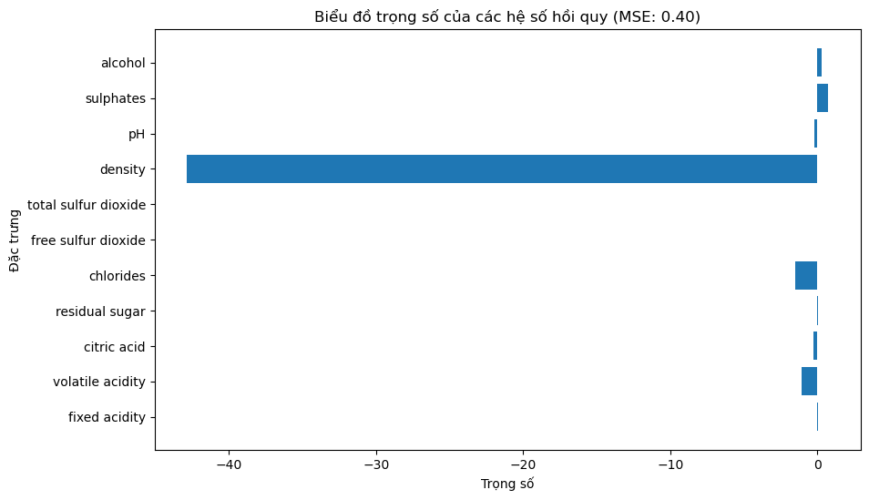

```python
# Hàm thêm cột 1 vào dữ liệu đầu vào
def add_intercept(X):
    return np.hstack((np.ones((X.shape[0], 1)), X))


# Hàm tính hệ số w dựa trên công thức bình phương tối thiểu
def linear_regression(X, y):
    X = add_intercept(X)
    XTX_inv = np.linalg.inv(X.T @ X)
    w = XTX_inv @ X.T @ y
    return w


# Hàm dự đoán đầu ra dựa trên dữ liệu đầu vào và hệ số w
def predict(X, theta, model_type="linear"):
    if model_type == "quadratic":
        X = np.hstack((X, X**2))
    elif model_type == "cubic":
        X = np.hstack((X, X**2, X**3))
    elif model_type == "linear_log":
        X = np.log(X + 1e-10)
    elif model_type == "log_linear":
        pass
    elif model_type == "log_log":
        X = np.log(X + 1e-10)
    X = add_intercept(X)
    return X @ theta


# Hàm tính độ đo Mean Squared Error
def mean_squared_error(y_true, y_pred):
    return np.mean((y_true - y_pred) ** 2)


# Hàm chính để minh họa biểu đồ trọng số của các hệ số hồi quy
def plot_weights_chart(X, y, features):
    # Chia dữ liệu thành tập huấn luyện và tập kiểm tra
    X_train, X_test, y_train, y_test = train_test_split(X, y)

    # Huấn luyện mô hình hồi quy tuyến tính
    w = linear_regression(X_train, y_train)

    # Tính toán MSE trên tập kiểm tra
    y_pred = predict(X_test, w)
    mse = mean_squared_error(y_test, y_pred)

    # Lấy trọng số của các đặc trưng (bỏ qua hệ số intercept)
    weights = w[1:]

    # Vẽ biểu đồ trọng số của các hệ số hồi quy
    plt.figure(figsize=(10, 6))
    plt.barh(features, weights)
    plt.xlabel("Trọng số")
    plt.ylabel("Đặc trưng")
    plt.title(f"Biểu đồ trọng số của các hệ số hồi quy (MSE: {mse:.2f})")
    plt.show()


# Gọi hàm để minh họa biểu đồ trọng số
plot_weights_chart(X, y, features)
```

## 3.4 Xây dựng mô hình hồi quy tuyến tính sử dụng duy nhất 1 đặc trưng cho kết quả tốt nhất

```
--> MSE (fixed acidity): 0.618635896786188
--> MSE (volatile acidity): 0.5469042872738817
--> MSE (citric acid): 0.6021543739404304
--> MSE (residual sugar): 0.6379281931892555
--> MSE (chlorides): 0.6226816857765969
--> MSE (free sulfur dioxide): 0.6297082594347166
--> MSE (total sulfur dioxide): 0.6148904930447838
--> MSE (density): 0.6064583366177981
--> MSE (pH): 0.6306431164583272
--> MSE (sulphates): 0.6022859111537175
--> MSE (alcohol): 0.4796090833834418
===> Best Feature: alcohol
===> Mean Squared Error (Best Feature): 0.4796090833834418
```

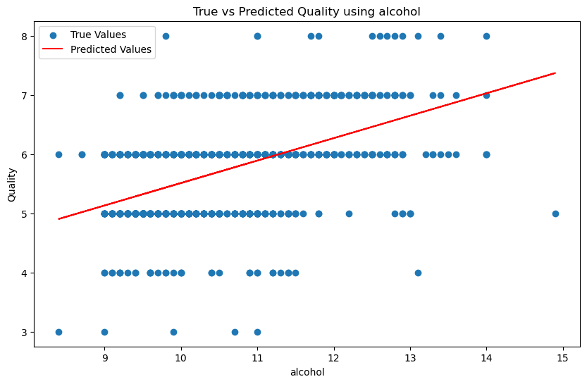

```python
# Hàm sử dụng 1 đặc trưng tốt nhất để dự đoán chất lượng rượu
def best_feature() -> None:
    best_mse = float("inf")
    best_feature = None
    best_w = None
    # Chia dữ liệu thành tập huấn luyện và tập kiểm tra
    X_train, X_test, y_train, y_test = train_test_split(X, y)
    for i in range(X_train.shape[1]):
        # Sử dụng 1 đặc trưng
        X_train_single = X_train[:, i].reshape(-1, 1)
        X_test_single = X_test[:, i].reshape(-1, 1)
        # Tính hệ số w
        w = linear_regression(X_train_single, y_train)
        # Dự đoán chất lượng rượu
        y_pred = predict(X_test_single, w)
        # Tính lỗi bình phương trung bình
        mse_single = mean_squared_error(y_test, y_pred)
        print(f"--> MSE ({features[i]}): {mse_single}")
        if mse_single < best_mse:
            best_mse = mse_single
            best_feature = i
            best_w = w

    print(f"===> Best Feature: {features[best_feature]}")
    print(f"===> Mean Squared Error (Best Feature): {best_mse}")
    # Vẽ biểu đồ dữ liệu
    plot_data(
        X[:, best_feature],
        y,
        predict(X[:, best_feature].reshape(-1, 1), best_w),
        features[best_feature],
    )


# Hàm vẽ biểu đồ dữ liệu
def plot_data(X_feature, y_true, y_pred, feature_name):
    plt.figure(figsize=(10, 6))
    plt.scatter(X_feature, y_true, label="True Values")
    plt.plot(X_feature, y_pred, color="red", label="Predicted Values")
    plt.xlabel(feature_name)
    plt.ylabel("Quality")
    plt.title(f"True vs Predicted Quality using {feature_name}")
    plt.legend()
    plt.show()


# Gọi hàm để tìm và minh họa đặc trưng tốt nhất
best_feature()
```

## 3.5 Xây dựng một mô hình của riêng để cho kết quả tốt nhất

Các bước thực hiện:

- Xây dựng mô hình hồi quy tuyến tính bậc 1: $y = w_0 + w_1x_1$
- Xây dựng mô hình hồi quy tuyến tính bậc 2: $y = w_0 + w_1x_1 + w_2x_1^2$
- Xây dựng mô hình hồi quy tuyến tính bậc 3: $y = w_0 + w_1x_1 + w_2x_1^2 + w_3x_1^3$
- Xây dựng mô hình tuyến tính - log: $y = w_0 + w_1\ln(x_1)$
- Xây dựng mô hình log - tuyến tính: $\ln(y) = w_0 + w_1x_1$
- Xây dựng mô hình log - log: $\ln(y) = w_0 + w_1\ln(x_1)$
- Đánh giá mô hình bằng độ đo MSE.
- Chọn ra mô hình tốt nhất.
- Trực quan hóa kết quả.
- In ra các hệ số của mô hình.
- Đánh giá mô hình trên tập kiểm tra.
- So sánh kết quả dự đoán với kết quả thực tế.

### 3.5.1 Mô hình $y = w_0 + w_1x_1 + w_2x_1^2$

```python
# Function to compute the coefficients of the quadratic regression equation - Model: Y = theta0 + theta1*X + theta2*X^2
def quadratic_regression(X: ArrayLike, y: ArrayLike) -> ArrayLike:
    X = np.hstack((X, X**2))
    X = add_intercept(X)
    XTX_inv = np.linalg.inv(X.T @ X)
    theta = XTX_inv @ X.T @ y
    return theta
```

### 3.5.2 Mô hình $y = w_0 + w_1x_1 + w_2x_1^2 + w_3x_1^3$

```python
# Function to compute the coefficients of the cubic regression equation - Model: Y = theta0 + theta1*X + theta2*X^2 + theta3*X^3
def cube_regression(X: ArrayLike, y: ArrayLike) -> ArrayLike:
    X = np.hstack((X, X**2, X**3))
    X = add_intercept(X)
    XTX_inv = np.linalg.inv(X.T @ X)
    theta = XTX_inv @ X.T @ y
    return theta
```

### 3.5.3 Mô hình $y = w_0 + w_1\ln(x_1)$

```python
# Function to compute the coefficients of the logarithmic regression equation - Model: Y = theta0 + theta1*ln(X)
def linear_log_regression(X: ArrayLike, y: ArrayLike) -> ArrayLike:
    X = np.log(X + 1e-10)
    X = add_intercept(X)
    XTX_inv = np.linalg.inv(X.T @ X)
    theta = XTX_inv @ X.T @ y
    return theta
```

### 3.5.4 Mô hình $\ln(y) = w_0 + w_1x_1$

```python
# Function to compute the coefficients of the logarithmic regression equation - Model: lnY = theta0 + theta1*X
def log_linear_regression(X: ArrayLike, y: ArrayLike) -> ArrayLike:
    y = np.log(y + 1e-10)
    X = add_intercept(X)
    XTX_inv = np.linalg.inv(X.T @ X)
    theta = XTX_inv @ X.T @ y
    return theta
```

### 3.5.5 Mô hình $\ln(y) = w_0 + w_1\ln(x_1)$

```python
# Function to compute the coefficients of the logarithmic regression equation - Model: lnY = theta0 + theta1*ln(X)
def log_log_regression(X: ArrayLike, y: ArrayLike) -> ArrayLike:
    X = np.log(X + 1e-10)
    y = np.log(y + 1e-10)
    X = add_intercept(X)
    XTX_inv = np.linalg.inv(X.T @ X)
    theta = XTX_inv @ X.T @ y
    return theta
```